# 15.8 Computational Technique

```r
require(mosaic) # mosaic operators and data used in this section
```

The basic software for hypothesis testing on parts of models involves the familiar `lm` and `summary` operators for generating the regression report and the `anova` operator for generating an **`ANOVA`** report on a model.

## ANOVA reports

The `anova` operator takes a model as an argument and produces the term-by term `ANOVA` report. To illustrate, consider this model of wages from the Current Population Survey data.

```r
Cps <-  CPS85 # from mosaicData
mod1 <-  lm( wage ~ married + age + educ, data = Cps)
anova(mod1)
```

```
## Analysis of Variance Table
##
## Response: wage
##            Df  Sum Sq Mean Sq  F value    Pr(>F)
## married     1   142.4  142.40   6.7404  0.009687 **
## age         1   338.5  338.48  16.0215 7.156e-05 ***
## educ        1  2398.7 2398.72 113.5405 < 2.2e-16 ***
## Residuals 530 11197.1   21.13
## ---
## Signif. codes:  0 '***' 0.001 '**' 0.01 '*' 0.05 '.' 0.1 ' ' 1
```

Note the small p-value on the `married` term: `0.0097`.

To change the order of the terms in the report, you can create a new model with the explanatory terms listed in a different order. For example, here’s the `ANOVA` on the same model, but with `married` last instead of first:

```r
mod2 <- lm( wage ~ age + educ + married, data = Cps)
anova(mod2)
```

```
## Analysis of Variance Table
##
## Response: wage
##            Df  Sum Sq Mean Sq  F value    Pr(>F)
## age         1   440.8  440.84  20.8668  6.13e-06 ***
## educ        1  2402.7 2402.75 113.7310 < 2.2e-16 ***
## married     1    36.0   36.01   1.7046    0.1923
## Residuals 530 11197.1   21.13
## ---
## Signif. codes:  0 '***' 0.001 '**' 0.01 '*' 0.05 '.' 0.1 ' ' 1
```

Now the p-value on `married` is large. This suggests that much of the variation in `wage` that is associated with `married` can also be accounted for by `age` and `educ` instead.

## Non-Parametric Statistics

It’s easy to confirm that this interaction term is statistically significant:

```r
Swim <-  SwimRecords  # in mosaicData
anova( lm( time ~ year * sex, data = Swim) )
```

```
## Analysis of Variance Table
##
## Response: time
##           Df Sum Sq Mean Sq F value    Pr(>F)
## year       1 3578.6  3578.6 324.738 < 2.2e-16 ***
## sex        1 1484.2  1484.2 134.688 < 2.2e-16 ***
## year:sex   1  296.7   296.7  26.922 2.826e-06 ***
## Residuals 58  639.2    11.0
## ---
## Signif. codes:  0 '***' 0.001 '**' 0.01 '*' 0.05 '.' 0.1 ' ' 1
```

The p-value on the interaction term is very small: $2.8 \times10^{-6}$.

To check whether this result might be influenced by the shape of the distribution of the `time` or `year` data, you can conduct a non-parametric test. Simply take the rank of each quantitative variable:

```r
mod <- lm( rank(time) ~ rank(year) * sex, data = Swim)
anova(mod)
```

```
## Analysis of Variance Table
##
## Response: rank(time)
##                Df  Sum Sq Mean Sq   F value Pr(>F)
## rank(year)      1 14320.5 14320.5 3755.7711 <2e-16 ***
## sex             1  5313.0  5313.0 1393.4135 <2e-16 ***
## rank(year):sex  1     0.9     0.9    0.2298 0.6335
## Residuals      58   221.1     3.8
## ---
## Signif. codes:  0 '***' 0.001 '**' 0.01 '*' 0.05 '.' 0.1 ' ' 1
```

With the rank-transformed data, the p-value on the interaction term is much larger: no evidence for an interaction between `year` and `sex`. You can see this directly in a plot of the data after rank-transforming `time`:

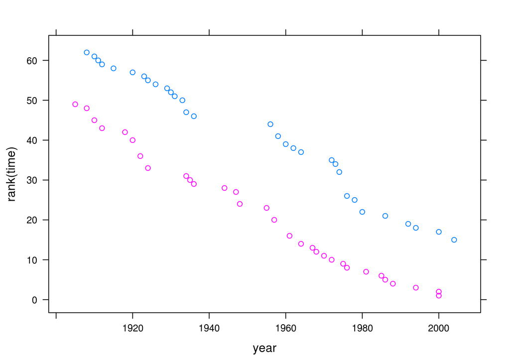

```r
xyplot( rank(time) ~ year, groups = sex, data = Swim)
```

The rank-transformed data suggest that women’s records are improving in about the same way as men’s. That is, new records are set by women at a rate similar to the rate at which men set them.